# Relationship between variables and MPG

Author: Armin Najarpour Foroushani

### Overview and Objectives

We are interested in exploring the relationship between different variables and miles per gallon (MPG) (outcome). Particularly the following two questions: 1) Which one is better for MPG: automatic or manual? 2) MPG difference between automatic and manual transmissions

These questions are answered using mtcars dataset in R.

### Analysis

mpg and am columns show miles per gallon and transmission (0 = automatic, 1 = manual).

A linear regression model was fitted with transmission as two level factor predictor and MPG as the outcome.

ggplot was used to visualize the data and the fitted lines.

```r
fit = lm(mpg ~ factor(am), data = mtcars)
summary(fit)$coef
```

```
##              Estimate Std. Error   t value     Pr(>|t|)
## (Intercept) 17.147368   1.124603 15.247492 1.133983e-15
## factor(am)1  7.244939   1.764422  4.106127 2.850207e-04
```

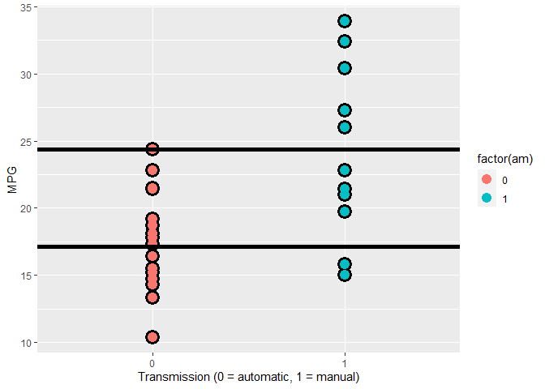

We compared mean MPG for manual and automatic transmissions.

```r
cat("automatic: ", mean(mtcars$mpg[mtcars$am == 0]))
```

```
## automatic:  17.14737
```

```r
cat("manual: ", mean(mtcars$mpg[mtcars$am == 1]))
```

```
## manual:  24.39231
```

Intercept for the automatic cars is 17.15 and for the manual is 24.4, and their mean values are 17.15 and 24.4.

t-test was applied to quantify the difference between automatic and manual transmissions:

```r
t.test(mtcars$mpg[mtcars$am==0],mtcars$mpg[mtcars$am==1],paired = FALSE,alternative = "two.sided",var.equal = FALSE)$p.value
```

```
## [1] 0.001373638
```

Difference between the automatic and manual cars is significant with 95% confidence interval (-11.3,-3.2).

```r
dfbetas(fit)[1:4, 2]
```

```
##      Mazda RX4  Mazda RX4 Wag     Datsun 710 Hornet 4 Drive
##    -0.15890518    -0.15890518    -0.07408166    -0.13342859
```

```r
er <- resid(fit)
yhat <- predict(fit)
max(abs(er -(mtcars$mpg - yhat)))
```

```
## [1] 4.840572e-14
```

Predicted values are the mean of each group and the residuals are the difference between each value and its mean.

Dependence of MPG on the other variables:

```r
summary(lm(mpg ~ ., data = mtcars))$coef[, 1]
```

```
## (Intercept)         cyl        disp          hp        drat          wt
## 12.30337416 -0.11144048  0.01333524 -0.02148212  0.78711097 -3.71530393
##        qsec          vs          am        gear        carb
##  0.82104075  0.31776281  2.52022689  0.65541302 -0.19941925
```

```r
t.test(mtcars$mpg,mtcars$am,paired = FALSE,alternative = "two.sided",var.equal = FALSE)$p.value
```

```
## [1] 2.151228e-18
```

```r
t.test(mtcars$mpg,mtcars$wt,paired = FALSE,alternative = "two.sided",var.equal = FALSE)$p.value
```

```
## [1] 1.027903e-16
```

So, transmission and weight are the most important predictors of MPG.